# rsmFlow: Design Audit, Prediction Precision, and Augmentation

# Design audit, prediction precision, and augmentation

**Role in the vignette curriculum.** This deep dive owns design generation, coding, non-orthogonality, estimability, prediction variance, FDS, VDG, rotatability, design comparison, and augmentation. Model interpretation and optimization are developed in later vignettes.

> The examples are intentionally not executed during vignette build in this development snapshot. Full runtime certification remains a separate release gate.

## 1. Why design quality is the first modeling question

Response-surface inference begins before a regression model is fitted. The experimental runs determine which effects can be estimated, how correlated those estimates will be, and where predictions will be precise. A perfectly estimated numerical optimum is meaningless if the fitted model is poorly supported in the region containing that optimum.

The core design questions are therefore:

1. Is the intended polynomial model estimable?
2. Are some model terms nearly redundant?
3. How much does scaling contribute to apparent numerical instability?
4. Is prediction variance reasonably distributed over the design space?
5. Is the design appropriate for parameter estimation, prediction, or both?
6. If information is weak, which additional runs improve it most efficiently?

These questions connect classical response-surface design theory (Box and Draper 1959) with modern diagnostics for imperfect real experiments (O’Driscoll and Ramirez 2015).

## 2. Start from the experimental region

```r
library(rsmFlow)

p <- system.file("extdata", "agronomy_rsm_nonorthogonal.csv", package="rsmFlow")
dat <- read.csv(p)
str(dat)
```

```
#> 'data.frame':    25 obs. of  4 variables:
#>  $ N         : num  120 85 155 85 155 85 155 85 155 120 ...
#>  $ K         : num  80 55 55 105 105 80 80 80 80 55 ...
#>  $ Irrigation: num  0.75 0.75 0.75 0.75 0.75 0.55 0.55 0.95 0.95 0.55 ...
#>  $ Yield     : num  8.8 5.72 7.35 6.96 8.98 ...
```

```r
summary(dat)
```

```
#>        N                K            Irrigation        Yield
#>  Min.   : 76.25   Min.   : 51.25   Min.   :0.490   Min.   :5.721
#>  1st Qu.:120.00   1st Qu.: 80.00   1st Qu.:0.750   1st Qu.:7.321
#>  Median :120.00   Median : 80.00   Median :0.750   Median :8.423
#>  Mean   :119.79   Mean   : 80.05   Mean   :0.748   Mean   :7.920
#>  3rd Qu.:120.00   3rd Qu.: 80.00   3rd Qu.:0.750   3rd Qu.:8.763
#>  Max.   :158.50   Max.   :110.00   Max.   :0.960   Max.   :8.979
```

Record natural units explicitly. Never allow coded coordinates to erase the scientific meaning of the factor limits.

```r
factor_ranges <- data.frame(
  factor = c("N", "K", "Irrigation"),
  lower = sapply(dat[c("N","K","Irrigation")], min),
  upper = sapply(dat[c("N","K","Irrigation")], max)
)
factor_ranges
```

```
#>                factor lower  upper
#> N                   N 76.25 158.50
#> K                   K 51.25 110.00
#> Irrigation Irrigation  0.49   0.96
```

A useful pre-analysis table contains response unit, factor units, lower and upper bounds, number of unique settings, replication, blocks, and infeasible combinations.

## 3. Coding and decoding

Coding puts factor displacements on comparable scales. For factor $X$, a common transformation is

$$x = \frac{X-X_0}{\Delta X}.$$

```r
coded <- rsm_code(
  dat,
  factors = c("N","K","Irrigation")
)
head(coded)
```

```
#>             N          K Irrigation    Yield
#> 1  0.06382979 -0.0212766  0.1063830 8.804629
#> 2 -0.78723404 -0.8723404  0.1063830 5.720626
#> 3  0.91489362 -0.8723404  0.1063830 7.348612
#> 4 -0.78723404  0.8297872  0.1063830 6.957880
#> 5  0.91489362  0.8297872  0.1063830 8.979375
#> 6 -0.78723404 -0.0212766 -0.7446809 6.035782
```

```r
coding <- attr(coded, "rsmFlow_coding")
coding
```

```
#> $center
#>          N          K Irrigation
#>    117.375     80.625      0.725
#>
#> $scale
#>          N          K Irrigation
#>     41.125     29.375      0.235
```

Return to natural units with:

```r
natural <- rsm_decode(coded, coding)
head(natural)
```

```
#>     N   K Irrigation    Yield
#> 1 120  80       0.75 8.804629
#> 2  85  55       0.75 5.720626
#> 3 155  55       0.75 7.348612
#> 4  85 105       0.75 6.957880
#> 5 155 105       0.75 8.979375
#> 6  85  80       0.55 6.035782
```

### Interpretation

Coding can improve numerical conditioning and makes geometric quantities easier to compare across factors. It does **not** create experimental information. A nearly aliased design remains nearly aliased after rescaling.

## 4. Generate standard response-surface designs

### 4.1 Central Composite Design

```r
ccd <- rsm_design(
  factors = c("N","K","Irrigation"),
  type = "ccd",
  n0 = 6,
  alpha = "rotatable",
  seed = 101
)
head(ccd)
```

```
#>    N  K Irrigation Block run.order std.order
#> 1  1  1         -1     1         1         4
#> 2  0  0          0     1         2        12
#> 3 -1  1          1     1         3         7
#> 4  0  0          0     1         4        13
#> 5  0  0          0     1         5        11
#> 6  1 -1          1     1         6         6
```

Face-centered and inscribed variants are available:

```r
ccf <- rsm_design(c("N","K","Irrigation"), type="ccd_face", n0=6, seed=101)
cci <- rsm_design(c("N","K","Irrigation"), type="ccd_inscribed", n0=6, seed=101)
```

### 4.2 Box-Behnken design

```r
bbd <- rsm_design(
  factors = c("N","K","Irrigation"),
  type = "bbd",
  n0 = 5,
  seed = 102
)
```

### 4.3 D- and I-oriented designs

```r
cand <- expand.grid(
  N = seq(-1, 1, length.out=9),
  K = seq(-1, 1, length.out=9),
  Irrigation = seq(-1, 1, length.out=7)
)

d_opt <- rsm_design(
  factors = c("N","K","Irrigation"),
  type = "d_optimal",
  runs = 20,
  candidates = cand,
  seed = 103
)

i_opt <- rsm_design(
  factors = c("N","K","Irrigation"),
  type = "i_optimal",
  runs = 20,
  candidates = cand,
  seed = 103
)
```

**Scientific distinction.** D-optimality emphasizes information for model coefficients. I-oriented criteria emphasize average prediction variance over a region. Exact criterion behavior depends on the backend and must be runtime-validated before formal design claims.

## 5. Custom and imperfect designs are first-class inputs

Real experiments can lose runs, inherit legacy layouts, or combine feasible points from operational constraints. `rsmFlow` does not require a textbook design to fit a model.

```r
custom <- rsm_design(
  factors = c("N","K","Irrigation"),
  type = "custom",
  data = dat[c("N","K","Irrigation")]
)
```

The important question becomes: **what information does this custom design support?**

## 6. Fit the intended model before auditing its information

```r
fit <- rsm_fit(
  dat,
  response = "Yield",
  factors = c("N","K","Irrigation"),
  order = 2
)
```

Audit:

```r
a <- rsm_design_audit(fit)
a
```

```
#> Design status: caution
#> Rank: 10 / 10  | condition number (scaled/raw): 28.284 / 1824800
#> Maximum absolute model-term correlation: 0.99388
#> - Strong term correlation indicates substantial non-orthogonality.
```

The audit should be read as a bundle of evidence rather than a single pass/fail score.

| Diagnostic | Main question |
| --- | --- |
| Rank | Are all requested terms estimable? |
| Aliases | Which terms are linearly dependent? |
| Condition number | Is the design matrix numerically unstable? |
| VIF-like inflation | Are term estimates strongly correlated? |
| Term correlation | Which columns of the model matrix move together? |
| Prediction variance | Where are predictions weakly supported? |
| D/A/E/G-like metrics | How informative is the design under different objectives? |
| Rotatability proxy | Does precision depend mainly on distance from center? |

## 7. Non-orthogonality is not automatic invalidity

```r
orth <- rsm_orthogonality(fit)
orth
```

```
#> $max_abs_correlation
#> [1] 0.993875
#>
#> $mean_abs_correlation
#> [1] 0.3567531
#>
#> $correlation
#>                             N             K    Irrigation        I(N^2)
#> N                1.000000e+00  2.786292e-05 -1.391363e-04  0.9928267334
#> K                2.786292e-05  1.000000e+00  4.639858e-05 -0.0002640523
#> Irrigation      -1.391363e-04  4.639858e-05  1.000000e+00  0.0013185721
#> I(N^2)           9.928267e-01 -2.640523e-04  1.318572e-03  1.0000000000
#> I(K^2)           9.546696e-04  9.919903e-01  1.589759e-03 -0.0006691650
#> I(Irrigation^2)  6.653372e-04 -2.218738e-04  9.938750e-01  0.0009512213
#> N:K              6.767932e-01  7.248231e-01 -6.053380e-05  0.6717269347
#> N:Irrigation     7.324537e-01  5.151321e-05  6.702271e-01  0.7281760863
#> K:Irrigation    -6.867531e-05  7.545473e-01  6.447149e-01  0.0006508248
#>                        I(K^2) I(Irrigation^2)           N:K N:Irrigation
#> N                9.546696e-04    6.653372e-04  0.6767931892 7.324537e-01
#> K                9.919903e-01   -2.218738e-04  0.7248230538 5.151321e-05
#> Irrigation       1.589759e-03    9.938750e-01 -0.0000605338 6.702271e-01
#> I(N^2)          -6.691650e-04    9.512213e-04  0.6717269347 7.281761e-01
#> I(K^2)           1.000000e+00    9.013792e-05  0.7196448113 1.765002e-03
#> I(Irrigation^2)  9.013792e-05    1.000000e+00  0.0002894671 6.667107e-01
#> N:K              7.196448e-01    2.894671e-04  1.0000000000 4.957422e-01
#> N:Irrigation     1.765002e-03    6.667107e-01  0.4957422183 1.000000e+00
#> K:Irrigation     7.494988e-01    6.405638e-01  0.5468525768 4.321208e-01
#>                  K:Irrigation
#> N               -6.867531e-05
#> K                7.545473e-01
#> Irrigation       6.447149e-01
#> I(N^2)           6.508248e-04
#> I(K^2)           7.494988e-01
#> I(Irrigation^2)  6.405638e-01
#> N:K              5.468526e-01
#> N:Irrigation     4.321208e-01
#> K:Irrigation     1.000000e+00
```

A full-rank non-orthogonal design still supports ordinary least squares. What changes is the covariance structure of estimated effects and predictions.

Potential consequences include:

- inflated standard errors;
- unstable coefficient signs in highly correlated parameterizations;
- difficulty interpreting isolated terms;
- nonuniform prediction variance;
- strong dependence of the optimum on a small part of the design region.

### What not to say

Avoid statements such as:

> “The design is non-orthogonal, therefore RSM cannot be used.”

A more defensible statement is:

> “The second-order model was full rank, but substantial term correlation and heterogeneous prediction precision reduced the reliability of individual coefficient interpretation in parts of the design space.”

## 8. Inspect prediction variance directly

```r
pv <- rsm_prediction_variance(
  fit,
  n = 31,
  scaled = TRUE
)
head(pv)
```

```
#>          N     K Irrigation prediction_variance
#> 1 76.25000 51.25       0.49            2.756910
#> 2 78.99167 51.25       0.49            2.534318
#> 3 81.73333 51.25       0.49            2.334960
#> 4 84.47500 51.25       0.49            2.157039
#> 5 87.21667 51.25       0.49            1.998887
#> 6 89.95833 51.25       0.49            1.858962
```

Plot it:

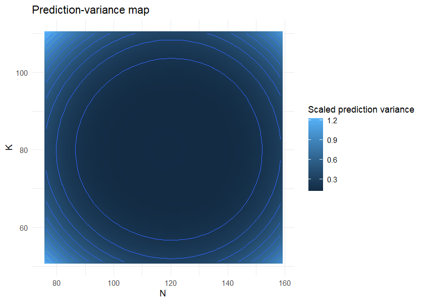

```r
rsm_plot(
  fit,
  type = "prediction_variance",
  interactive = FALSE
)
```

### Interpretation

Prediction variance is often more actionable than coefficient correlation when the scientific objective is optimization. Ask:

1. Is the fitted optimum located where prediction variance is low or high?
2. Are boundary regions much less precise than the center?
3. Does the design provide acceptable precision throughout the feasible operating region?

## 9. Fraction of Design Space

```r
fds <- rsm_fds(
  fit,
  n = 20000,
  seed = 202
)
head(fds)
```

```
#>       fraction scaled_prediction_variance
#> 1 5.080526e-05                   3.141647
#> 2 1.016105e-04                   3.145012
#> 3 1.524158e-04                   3.145459
#> 4 2.032211e-04                   3.145810
#> 5 2.540263e-04                   3.146077
#> 6 3.048316e-04                   3.146385
```

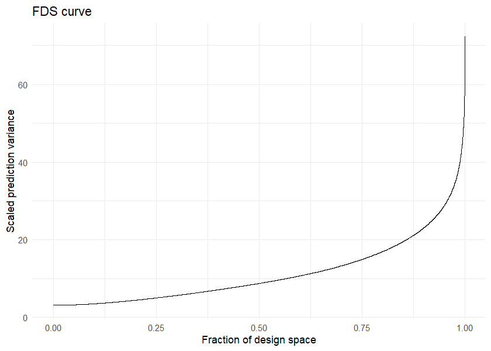

```r
rsm_plot(fit, type="fds")
```

The FDS curve expresses how much of the region is covered below successive prediction-variance levels.

### Interpretation

Two designs can have similar determinant-based efficiency but different distributions of prediction variance. FDS is useful when broad-region prediction quality matters.

## 10. Variance Dispersion Graph

```r
vdg <- rsm_vdg(
  fit,
  radii = seq(0, 1, length.out=15),
  points = 1500,
  seed = 203
)
vdg
```

```
#>        radius  min_spv mean_spv   max_spv      sd_spv
#> 1  0.00000000 3.335028 3.335028  3.335028          NA
#> 2  0.07142857 3.318926 3.327659  3.337775 0.005528947
#> 3  0.14285714 3.294879 3.305981  3.323509 0.007654060
#> 4  0.21428571 3.267024 3.277981  3.292527 0.005827360
#> 5  0.28571429 3.235361 3.253208  3.295791 0.014966634
#> 6  0.35714286 3.194954 3.245694  3.350382 0.042927741
#> 7  0.42857143 3.156096 3.275497  3.473654 0.089947747
#> 8  0.50000000 3.141397 3.373557  3.694577 0.154784021
#> 9  0.57142857 3.172384 3.535390  4.045966 0.241222828
#> 10 0.64285714 3.272973 3.828552  4.563012 0.370381884
#> 11 0.71428571 3.474852 4.277745  5.293041 0.505841639
#> 12 0.78571429 3.810741 4.960765  6.273360 0.690914526
#> 13 0.85714286 4.312021 5.741913  7.557485 0.917955555
#> 14 0.92857143 5.027977 6.916837  9.202603 1.167388218
#> 15 1.00000000 6.002330 8.421411 11.257379 1.440888054
```

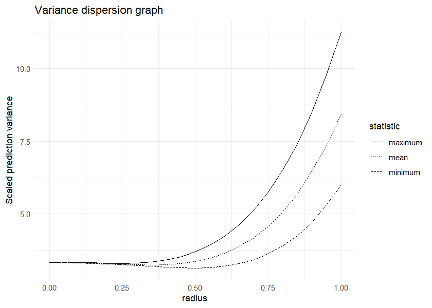

```r
rsm_plot(fit, type="vdg")
```

VDG summarizes prediction variance at increasing radii from the design center. It helps reveal whether precision changes directionally or primarily with distance.

## 11. Rotatability

```r
rot <- rsm_rotatability(
  fit,
  radii = c(0.25, 0.50, 0.75, 1.0),
  points = 1000,
  seed = 204
)
rot
```

```
#>   radius  mean_spv      cv_spv max_min_ratio
#> 1   0.25 0.1305849 0.002377085      1.010527
#> 2   0.50 0.1341157 0.045819808      1.175896
#> 3   0.75 0.1817840 0.130061197      1.585453
#> 4   1.00 0.3371402 0.174145152      1.874923
```

### Interpretation

Rotatability is desirable when equal-distance points should have comparable precision regardless of direction. It is not a universal requirement. A constrained agronomic region may make directional precision more relevant than perfect rotational symmetry.

## 12. Compare competing designs using several criteria

```r
cmp <- rsm_compare_designs(
  CCD = ccd,
  CCF = ccf,
  BBD = bbd,
  Dopt = d_opt,
  factors = c("N","K","Irrigation"),
  order = 2
)
cmp
```

```
#>   design runs parameters rank estimable condition_number
#> 1    CCD   26         10   10      TRUE         2.312009
#> 2    CCF   26         10   10      TRUE         3.063594
#> 3    BBD   17         10   10      TRUE         2.233790
#> 4   Dopt   20         10   10      TRUE         4.058939
#>   max_abs_term_correlation min_information_eigenvalue
#> 1               0.04912184                   23.77195
#> 2               0.67500000                    8.12500
#> 3               0.05555556                   15.11111
#> 4               0.13514748                   12.84136
```

Do not turn this into a single leaderboard. A design can be attractive for coefficient estimation but less attractive for broad prediction or operational feasibility.

## 13. Design augmentation

Suppose the original experiment has already been performed and the audit reveals poor precision. The package can propose additional settings without deleting or altering observed runs.

```r
aug_D <- rsm_augment(
  fit,
  n_add = 6,
  objective = "D",
  seed = 205
)
aug_D
```

```
#>          N      K Irrigation
#> 73   76.25 110.00       0.49
#> 1    76.25  51.25       0.49
#> 81  158.50 110.00       0.49
#> 9   158.50  51.25       0.49
#> 721  76.25 110.00       0.96
#> 649  76.25  51.25       0.96
```

Other objectives:

```r
aug_A <- rsm_augment(fit, n_add=6, objective="A", seed=205)
aug_I <- rsm_augment(fit, n_add=6, objective="I", seed=205)
aug_G <- rsm_augment(fit, n_add=6, objective="G", seed=205)
aug_k <- rsm_augment(fit, n_add=6, objective="condition", seed=205)
```

### Scientific workflow for augmentation

1. Preserve the original observations.
2. Define feasible candidate settings.
3. Choose an objective connected to the scientific goal.
4. Inspect proposed additions for physical feasibility.
5. Compare predicted information before and after augmentation.
6. Conduct the new experimental runs.
7. Refit using measured responses.

`rsm_augment()` proposes settings. It never fabricates responses.

## 14. A reproducible comparison before and after augmentation

```r
# Schematic: after physically conducting the proposed runs,
# append measured responses and refit.

# dat_augmented <- rbind(dat, measured_new_runs)
# fit_augmented <- rsm_fit(
#   dat_augmented, "Yield",
#   c("N","K","Irrigation"), order=2
# )
#
# rsm_compare_designs(
#   Original = dat,
#   Augmented = dat_augmented,
#   factors = c("N","K","Irrigation"),
#   order = 2
# )
```

Never append model-predicted responses and call the resulting object an augmented experiment.

## 15. Design graphics for teaching

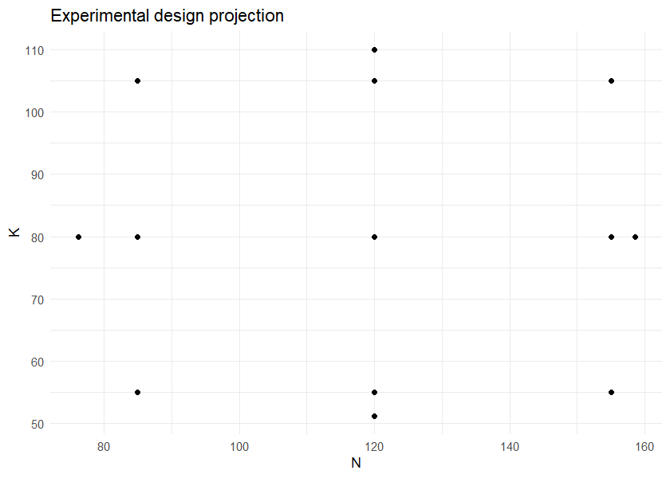

```r
rsm_plot(fit, type="design")
```

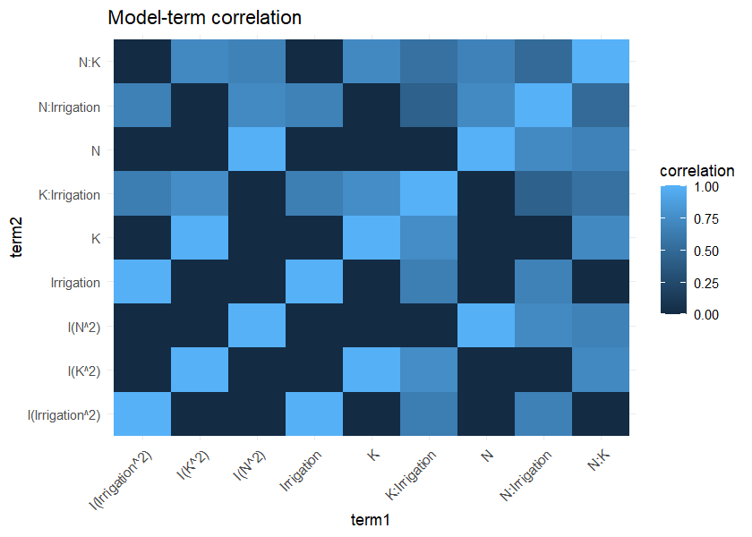

```r
rsm_plot(fit, type="term_correlation")
```

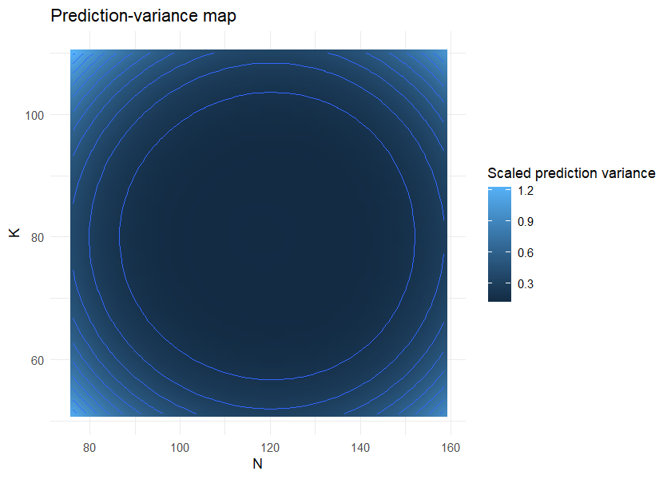

```r
rsm_plot(fit, type="prediction_variance")
```

For three or more factors, use slices and conditional views rather than trying to display the full geometry in one panel.

## 16. Three realistic design scenarios

### Scenario A: textbook CCD

Goal: teach curvature, center replication, and rotatability.

```r
des_A <- rsm_design(
  factors=c("N","P"),
  type="ccd",
  n0=6,
  alpha="rotatable",
  seed=300
)
```

### Scenario B: constrained face-centered design

Goal: avoid axial points outside practical factor limits.

```r
des_B <- rsm_design(
  factors=c("Temperature","Moisture","Time"),
  type="ccd_face",
  n0=5,
  seed=301
)
```

### Scenario C: legacy non-orthogonal field trial

Goal: quantify what can still be estimated and where prediction is weak.

```r
dat_C <- read.csv(p)
fit_C <- rsm_fit(dat_C, "Yield", c("N","K","Irrigation"), order=2)
rsm_design_audit(fit_C)
```

```
#> Design status: caution
#> Rank: 10 / 10  | condition number (scaled/raw): 28.284 / 1824800
#> Maximum absolute model-term correlation: 0.99388
#> - Strong term correlation indicates substantial non-orthogonality.
```

```r
rsm_fds(fit_C)
```

```
#>           fraction scaled_prediction_variance
#> 1     5.080526e-05                   3.141647
#> 2     1.016105e-04                   3.145012
#> 3     1.524158e-04                   3.145459
#> 4     2.032211e-04                   3.145810
#> 5     2.540263e-04                   3.146077
#> 6     3.048316e-04                   3.146385
#> 7     3.556368e-04                   3.148095
#> 8     4.064421e-04                   3.149025
#> 9     4.572474e-04                   3.149608
#> 10    5.080526e-04                   3.149708
#> 11    5.588579e-04                   3.149959
#> 12    6.096632e-04                   3.152313
#> 13    6.604684e-04                   3.152448
#> 14    7.112737e-04                   3.152628
```

[output cut: 19669 more lines]

```r
rsm_vdg(fit_C)
```

```
#>    radius  min_spv mean_spv   max_spv      sd_spv
#> 1    0.00 3.335028 3.335028  3.335028          NA
#> 2    0.05 3.324867 3.331095  3.338651 0.003932447
#> 3    0.10 3.310052 3.320538  3.334175 0.007016210
#> 4    0.15 3.292163 3.303868  3.321110 0.007985651
#> 5    0.20 3.272535 3.284113  3.299905 0.006215707
#> 6    0.25 3.252377 3.264884  3.286677 0.008075639
#> 7    0.30 3.228040 3.250123  3.302212 0.019492521
#> 8    0.35 3.199456 3.246550  3.342022 0.040748854
#> 9    0.40 3.169833 3.257244  3.414064 0.066890799
#> 10   0.45 3.148837 3.300088  3.528348 0.108560068
#> 11   0.50 3.141286 3.363889  3.693090 0.157678729
#> 12   0.55 3.156925 3.474424  3.923538 0.209592073
#> 13   0.60 3.203275 3.652469  4.231648 0.281016645
#> 14   0.65 3.290536 3.872036  4.622792 0.380424964
#> 15   0.70 3.424746 4.181167  5.123316 0.467931253
#> 16   0.75 3.622475 4.567539  5.748251 0.604160277
#> 17   0.80 3.895384 5.061437  6.506625 0.716973657
#> 18   0.85 4.252485 5.685670  7.415306 0.889759473
#> 19   0.90 4.713564 6.474372  8.495653 1.054349470
#> 20   0.95 5.298725 7.322924  9.775312 1.263812287
#> 21   1.00 6.003413 8.421107 11.262301 1.520077998
```

## 17. Common mistakes

### Mistake 1: using VIF as a binary acceptance rule

VIF-like inflation is evidence about term dependence, not a universal reject threshold for RSM.

### Mistake 2: diagnosing only the fitted coefficients

Prediction precision can be poor even when coefficient tables appear stable.

### Mistake 3: declaring D-optimality sufficient for every goal

If the primary objective is broad prediction or optimization in a specified region, prediction-oriented criteria should also be inspected.

### Mistake 4: adding arbitrary runs

Augmentation should be criterion-driven and physically feasible.

### Mistake 5: forgetting the experimental boundary

A design is defined over a region, not over all real-number factor combinations.

## 18. Minimum reporting checklist for design quality

- Natural factor units and bounds reported.
- Design family or origin described.
- Coding transformation documented when used.
- Intended model order declared before audit.
- Rank/estimability checked.
- Severe aliases or correlations reported.
- Raw and scaled conditioning distinguished where relevant.
- Prediction variance assessed for optimization studies.
- FDS/VDG used when region-wide precision is important.
- Rotatability interpreted as a design property, not a universal requirement.
- Augmentation objective and candidate region documented.
- Proposed runs distinguished from observed runs.

## 19. Where to go next

Continue to **Classical RSM, Geometry, and Diagnostics** for model hierarchy, lack of fit, canonical analysis, steepest paths, and ridge behavior. Optimization is intentionally deferred until model adequacy and geometry have been established.

Box, G. E. P., and Norman R. Draper. 1959. “A Basis for the Selection of a Response Surface Design.” *Journal of the American Statistical Association* 54 (287): 622–54. https://doi.org/10.1080/01621459.1959.10501525.

O’Driscoll, Diarmuid, and Donald E. Ramirez. 2015. “Response Surface Designs Using the Generalized Variance Inflation Factors.” *Cogent Mathematics* 2 (1): 1053728. https://doi.org/10.1080/23311835.2015.1053728.